# Answer_HW5

## R Markdown

These are the solutions provided by Hyndman

# Ex 1

> Consider the `pigs` series — the number of pigs slaughtered in Victoria each month.
> 1. Use the `ses` function in R to find the optimal values of $\alpha$ and $\ell_0$, and generate forecasts for the next four months.

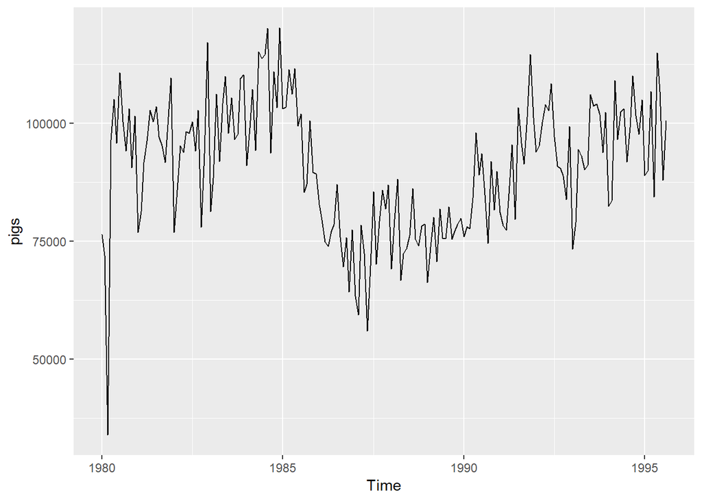

```r
autoplot(pigs)
```

```r
fcast.ses <- ses(pigs, h=4)
summary(fcast.ses)
```

```
##
## Forecast method: Simple exponential smoothing
##
## Model Information:
## Simple exponential smoothing
##
## Call:
##  ses(y = pigs, h = 4)
##
##   Smoothing parameters:
##     alpha = 0.2971
##
##   Initial states:
##     l = 77260.0561
##
##   sigma:  10309
##
##    AIC   AICc    BIC
## 4463.0 4463.1 4472.7
##
## Error measures:
##                  ME  RMSE    MAE      MPE  MAPE    MASE     ACF1
## Training set 385.87 10254 7961.4 -0.92265 9.274 0.79662 0.012822
##
## Forecasts:
##          Point Forecast Lo 80  Hi 80 Lo 95  Hi 95
## Sep 1995          98816 85605 112027 78612 119021
## Oct 1995          98816 85035 112598 77739 119894
## Nov 1995          98816 84486 113146 76900 120732
## Dec 1995          98816 83958 113674 76093 121540
```

> 2. Compute a 95% prediction interval for the first forecast using $\hat{y} \pm 1.96s$ where $s$ is the standard deviation of the residuals. Compare your interval with the interval produced by R.

```r
sd.ses <- sqrt(var(residuals(fcast.ses)))
f1 <- head(fcast.ses[["mean"]],1)
c(Lower95 = f1 - 1.96 * sd.ses,
  Upper95 = f1 + 1.96 * sd.ses)
```

```
## Lower95 Upper95
##   78680  118953
```

The intervals are close but not identical. This is because R estimates the variance of the residuals differently, taking account of the degrees of freedom properly.

```r
sd.ses <- sqrt(sum(residuals(fcast.ses)^2)/(length(pigs)-2))
c(Lower95 = f1 - 1.96 * sd.ses,
  Upper95 = f1 + 1.96 * sd.ses)
```

```
## Lower95 Upper95
##   78612  119021
```

# Ex 2

> Write your own function to implement simple exponential smoothing. The function should take arguments `y` (the time series), `alpha` (the smoothing parameter $\alpha$) and `level` (the initial level $\ell_0$). It should return the forecast of the next observation in the series. Does it give the same forecast as `ses`?

```r
myses <- function(y, alpha, level)
{
  n <- length(y)
  yhat <- numeric(n+1)
  yhat[1] <- level
  for(i in 2:(n+1)) {
    yhat[i] <- alpha * y[i-1] + (1 - alpha) * yhat[i-1]
  }
  return(tail(yhat,1))
}

c(my_forecast=myses(pigs, 0.2971, 77260.0561),
  R_forecast=ses(pigs, h = 1)[["mean"]])
```

```
## my_forecast  R_forecast
##       98816       98816
```

# Ex 3

> Modify your function from Q2 to return the sum of squared errors rather than the forecast of the next observation. Then use the `optim` function to find the optimal values of $\alpha$ and $\ell_0$. Do you get the same values as the `ses` function?

```r
myses.sse <- function(par, y)
{
  alpha <- par[1]
  level <- par[2]
  n <- length(y)
  yhat <- numeric(n)
  yhat[1] <- level
  for(i in 2:n) {
    yhat[i] <- alpha * y[i-1] + (1 - alpha) * yhat[i-1]
  }
  return(sum((y - yhat)^2))
}

options(digits=8)
optim(c(0.1, pigs[1]), myses.sse, y=pigs)$par
```

```
## [1] 2.9711897e-01 7.7265875e+04
```

```r
fcast.ses$model$par
```

```
##         alpha             l
## 2.9714883e-01 7.7260056e+04
```

Similar, but not identical estimates. This is due to different starting values being used.

# Ex 4

```r
myses.sse <- function(par, y)
{
  alpha <- par[1]
  level <- par[2]
  n <- length(y)
  yhat <- numeric(n)
  yhat[1] <- level
  for(i in 2:n) {
    yhat[i] <- alpha * y[i-1] + (1 - alpha) * yhat[i-1]
  }
  return(sum((y - yhat)^2))
}
myses <- function(y, h=10)
{
  par <- optim(c(0.1, y[1]), myses.sse, y=y)$par
  alpha <- par[1]
  level <- par[2]
  n <- length(y)
  yhat <- numeric(n+1)
  yhat[1] <- level
  for(i in 2:(n+1)) {
    yhat[i] <- alpha * y[i-1] + (1 - alpha) * yhat[i-1]
  }
  return(rep(yhat[n+1], h))
}
# Usage:
myses(pigs)
```

```
##  [1] 98816 98816 98816 98816 98816 98816 98816 98816 98816 98816
```

```r
# Compare:
ses(pigs)
```

```
##          Point Forecast Lo 80  Hi 80 Lo 95  Hi 95
## Sep 1995          98816 85605 112027 78612 119021
## Oct 1995          98816 85035 112598 77739 119894
## Nov 1995          98816 84486 113146 76900 120732
## Dec 1995          98816 83958 113674 76093 121540
## Jan 1996          98816 83449 114184 75313 122320
## Feb 1996          98816 82955 114678 74559 123074
## Mar 1996          98816 82476 115156 73827 123806
## Apr 1996          98816 82012 115621 73116 124517
## May 1996          98816 81559 116074 72424 125209
## Jun 1996          98816 81118 116515 71749 125883
```

# Ex 5

> Data set `books` contains the daily sales of paperback and hardcover books at the same store. The task is to forecast the next four daysâ???T sales for paperback and hardcover books.
> 1. Plot the series and discuss the main features of the data.

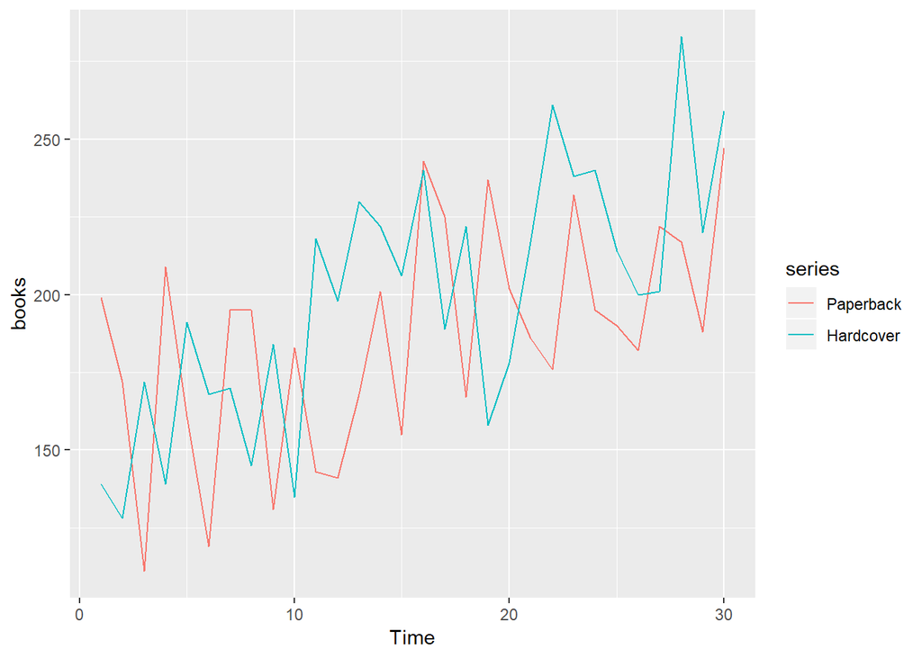

```r
autoplot(books)
```

Both series are trended, with a similar slope. There is no obvious weekly seasonality.

> 2. Use the `ses` function to forecast each series, and plot the forecasts.

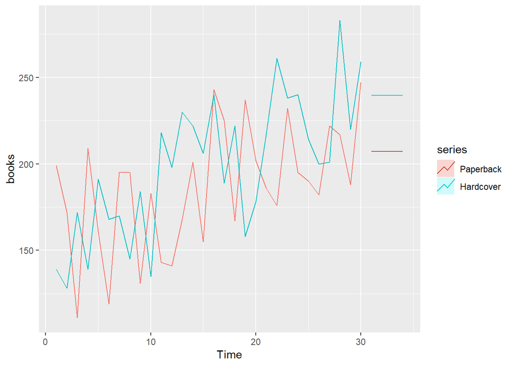

```r
fcast1 <- ses(books[,"Hardcover"], h=4)
fcast2 <- ses(books[,"Paperback"], h=4)
autoplot(books) +
  autolayer(fcast1, series="Hardcover", PI=FALSE) +
  autolayer(fcast2, series="Paperback", PI=FALSE)
```

> 3. Compute the RMSE values for the training data in each case.

```r
accuracy(fcast1)
```

```
##                  ME   RMSE    MAE    MPE   MAPE    MASE     ACF1
## Training set 9.1667 31.931 26.773 2.6362 13.395 0.79879 -0.14178
```

```r
accuracy(fcast2)
```

```
##                 ME   RMSE    MAE     MPE   MAPE    MASE     ACF1
## Training set 7.176 33.638 27.843 0.47361 15.578 0.70213 -0.21175
```

# Ex 6

> 1. Now apply Holtâ???Ts linear method to the `paperback` and `hardback` series and compute four-day forecasts in each case.

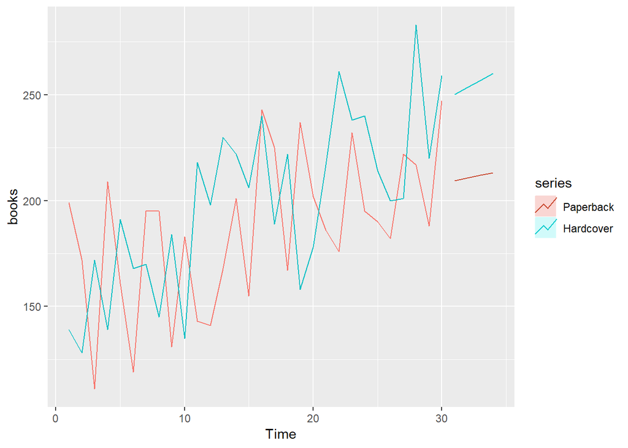

```r
fcast1 <- holt(books[,"Hardcover"], h=4)
fcast2 <- holt(books[,"Paperback"], h=4)
autoplot(books) +
  autolayer(fcast1, series="Hardcover", PI=FALSE) +
  autolayer(fcast2, series="Paperback", PI=FALSE)
```

> 2. Compare the RMSE measures of Holtâ???Ts method for the two series to those of simple exponential smoothing in the previous question. (Remember that Holtâ???Ts method is using one more parameter than SES.) Discuss the merits of the two forecasting methods for these data sets.

```r
accuracy(fcast1)
```

```
##                    ME   RMSE    MAE     MPE   MAPE    MASE      ACF1
## Training set -0.13579 27.194 23.156 -2.1148 12.163 0.69086 -0.032452
```

```r
accuracy(fcast2)
```

```
##                   ME   RMSE    MAE     MPE   MAPE    MASE     ACF1
## Training set -3.7172 31.137 26.181 -5.5085 15.584 0.66021 -0.17508
```

There’s been a big redution in RMSE, even allowing for the extra parameter. That’s not surprising as these series are clearly trended.

> 3. Compare the forecasts for the two series using both methods. Which do you think is best?

The results from `holt` are all higher than those from `ses` because it allows for the increasing trend.

Holt’s method is to be preferred here.

> 4. Calculate a 95% prediction interval for the first forecast for each series, using the RMSE values and assuming normal errors. Compare your intervals with those produced using `ses` and `holt`.

```r
s <- sqrt(fcast1$model$mse)
High <- fcast1$mean[1] + 1.96*s
Low <- fcast1$mean[1] - 1.96*s
fcast1
```

```
##    Point Forecast  Lo 80  Hi 80  Lo 95  Hi 95
## 31         250.17 212.74 287.61 192.92 307.43
## 32         253.48 216.04 290.91 196.22 310.73
## 33         256.78 219.34 294.21 199.53 314.03
## 34         260.08 222.65 297.52 202.83 317.33
```

```r
c(Low = Low, High = High)
```

```
##    Low   High
## 196.87 303.47
```

```r
s <- sqrt(fcast2$model$mse)
High <- fcast2$mean[1] + 1.96*s
Low <- fcast2$mean[1] - 1.96*s
fcast2
```

```
##    Point Forecast  Lo 80  Hi 80  Lo 95  Hi 95
## 31         209.47 166.60 252.33 143.91 275.02
## 32         210.72 167.85 253.58 145.16 276.27
## 33         211.97 169.11 254.83 146.41 277.52
## 34         213.22 170.36 256.08 147.67 278.77
```

```r
c(Low = Low, High = High)
```

```
##    Low   High
## 148.44 270.50
```

As with Exercise 1b, `holt()` is estimating the standard deviation of the results using a method that takes account of the degrees of freedom. So the results are slightly different.

# Ex 7

> For this exercise, use data set `eggs`, the price of a dozen eggs in the United States from 1900–1993. Experiment with the various options in the `holt()` function to see how much the forecasts change with damped trend, or with a Box-Cox transformation. Try to develop an intuition of what each argument is doing to the forecasts.

> [Hint: use `h=100` when calling `holt()` so you can clearly see the differences between the various options when plotting the forecasts.]

> Which model gives the best RMSE?

```r
# Best model:
fc <- holt(eggs, h=100, lambda=0.17, damped=FALSE)
accuracy(fc)
```

```
##                  ME   RMSE    MAE      MPE   MAPE    MASE    ACF1
## Training set 1.0926 26.382 19.042 -0.96935 9.6486 0.93933 0.03752
```